# Exploratory Data Analysis - Customer Churn

## 9.6 Churn Rate Berdasarkan Support Calls

**Tampilkan / Sembunyikan Kode**

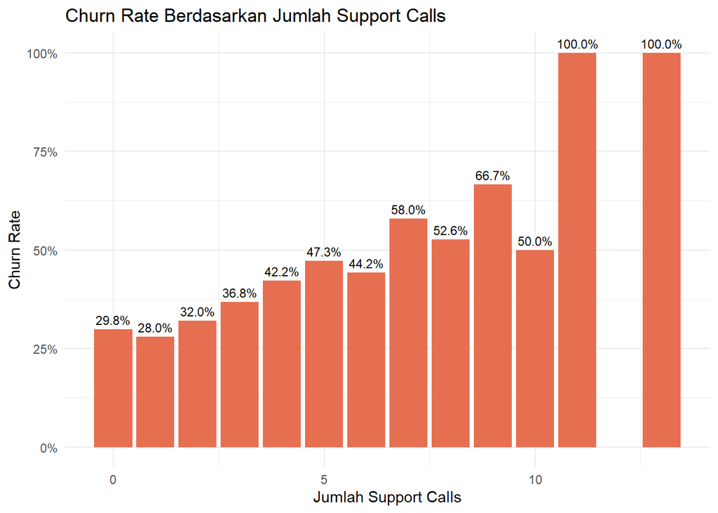

```r
support_churn <- customer_churn %>%
  group_by(support_calls) %>%
  summarise(
    total_customer = n(),
    total_churn = sum(churn == "Churn"),
    churn_rate = total_churn / total_customer,
    .groups = "drop"
  )

ggplot(support_churn,
       aes(x = support_calls, y = churn_rate)) +
  geom_col(fill = "#E76F51") +
  geom_text(
    aes(label = percent(churn_rate, accuracy = 0.1)),
    vjust = -0.5,
    size = 3
  ) +
  scale_y_continuous(labels = percent) +
  labs(
    title = "Churn Rate Berdasarkan Jumlah Support Calls",
    x = "Jumlah Support Calls",
    y = "Churn Rate"
  ) +
  theme_minimal()
```

## 9.7 Hubungan Keluhan dan Support Calls

**Tampilkan / Sembunyikan Kode**

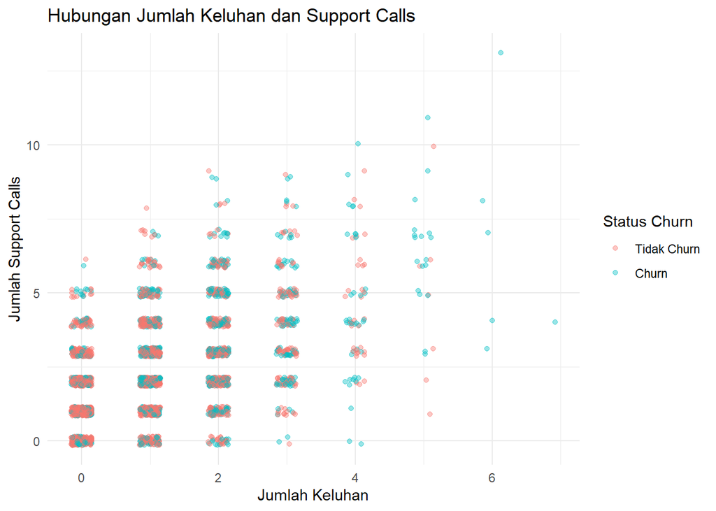

```r
ggplot(customer_churn,
       aes(x = num_complaints,
           y = support_calls,
           color = churn)) +
  geom_jitter(
    alpha = 0.4,
    width = 0.15,
    height = 0.15
  ) +
  labs(
    title = "Hubungan Jumlah Keluhan dan Support Calls",
    x = "Jumlah Keluhan",
    y = "Jumlah Support Calls",
    color = "Status Churn"
  ) +
  theme_minimal()
```

# 10 Relationship Between Variables

Bagian ini digunakan untuk melihat hubungan antara beberapa variabel numerik.

## 10.1 Hubungan Tenure dan Total Charges

**Tampilkan / Sembunyikan Kode**

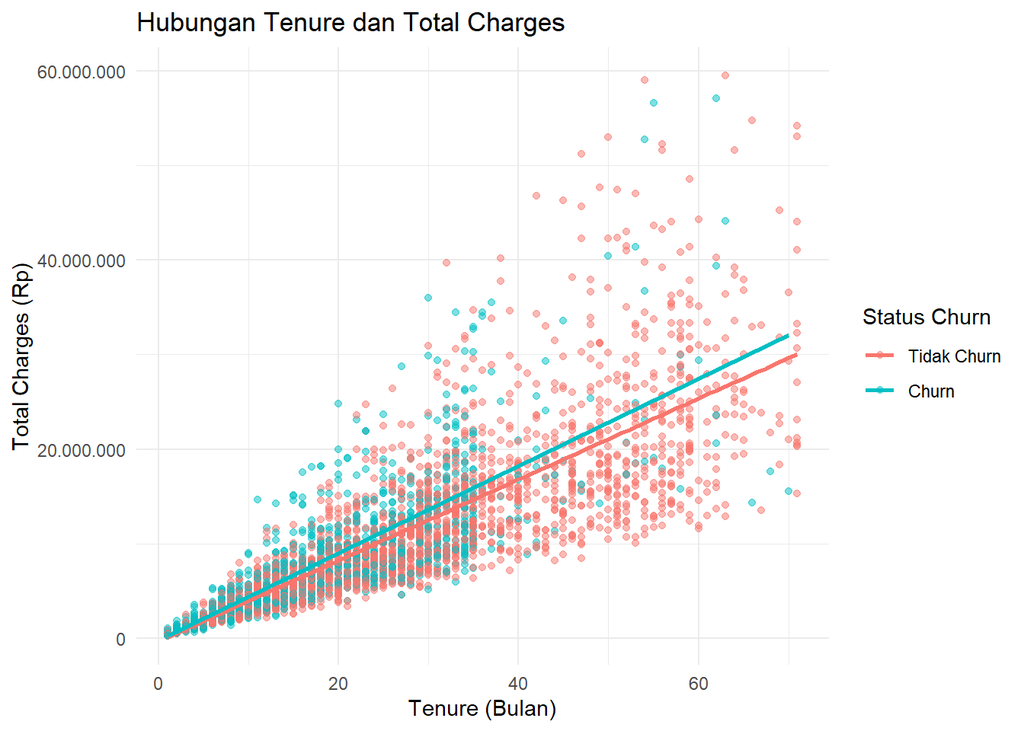

```r
ggplot(customer_churn,
       aes(x = tenure_months,
           y = total_charges,
           color = churn)) +
  geom_point(alpha = 0.5, na.rm = TRUE) +
  geom_smooth(
    method = "lm",
    se = FALSE,
    na.rm = TRUE
  ) +
  scale_y_continuous(labels = label_number(big.mark = ".")) +
  labs(
    title = "Hubungan Tenure dan Total Charges",
    x = "Tenure (Bulan)",
    y = "Total Charges (Rp)",
    color = "Status Churn"
  ) +
  theme_minimal()
```

## 10.2 Hubungan Tenure dan Monthly Charges

**Tampilkan / Sembunyikan Kode**

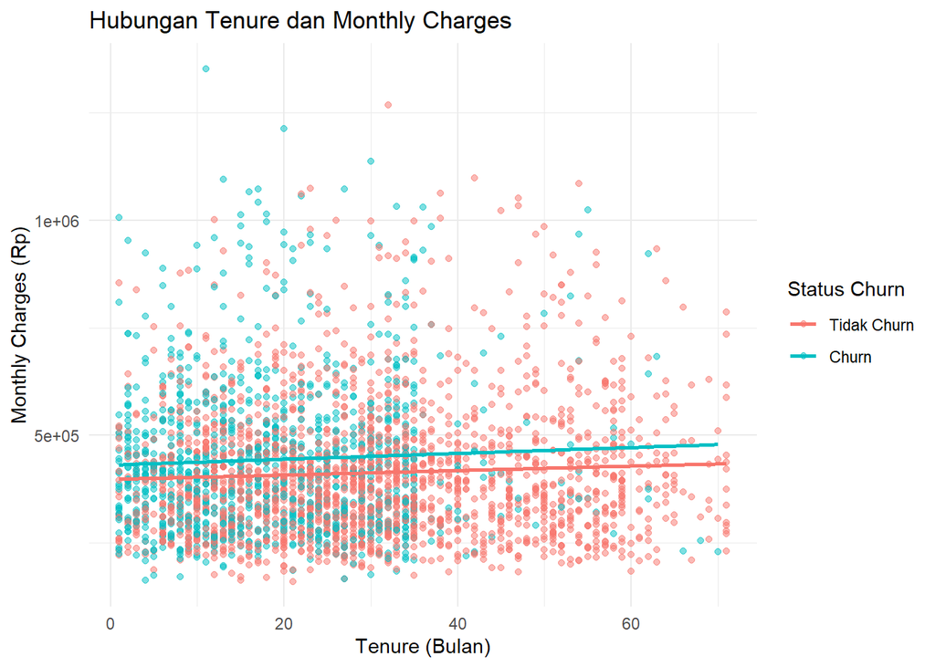

```r
ggplot(customer_churn,
       aes(x = tenure_months,
           y = monthly_charges,
           color = churn)) +
  geom_point(alpha = 0.5) +
  geom_smooth(
    method = "lm",
    se = FALSE
  ) +
  labs(
    title = "Hubungan Tenure dan Monthly Charges",
    x = "Tenure (Bulan)",
    y = "Monthly Charges (Rp)",
    color = "Status Churn"
  ) +
  theme_minimal()
```

## 10.3 Korelasi Antarvariabel Numerik

**Tampilkan / Sembunyikan Kode**

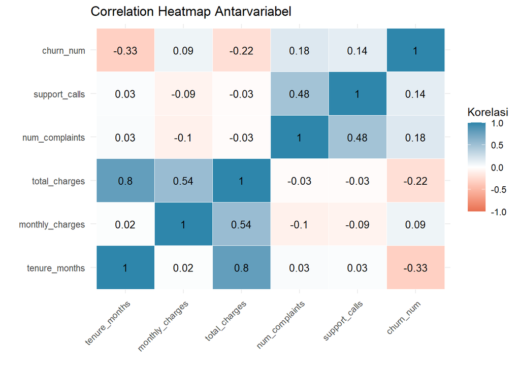

```r
numeric_data <- customer_churn %>%
  select(
    tenure_months,
    monthly_charges,
    total_charges,
    num_complaints,
    support_calls,
    churn_num
  )

correlation_matrix <- cor(
  numeric_data,
  use = "pairwise.complete.obs"
)

correlation_data <- as.data.frame(
  as.table(correlation_matrix)
)

ggplot(
  correlation_data,
  aes(x = Var1, y = Var2, fill = Freq)
) +
  geom_tile(color = "white") +
  geom_text(
    aes(label = round(Freq, 2)),
    size = 3.5
  ) +
  scale_fill_gradient2(
    low = "#E76F51",
    mid = "white",
    high = "#2E86AB",
    midpoint = 0,
    limits = c(-1, 1)
  ) +
  labs(
    title = "Correlation Heatmap Antarvariabel",
    x = "",
    y = "",
    fill = "Korelasi"
  ) +
  theme_minimal() +
  theme(
    axis.text.x = element_text(
      angle = 45,
      hjust = 1
    )
  )
```

# 11 Comparative Analysis

Bagian ini menggabungkan beberapa variabel kategorikal untuk melihat pola churn secara lebih mendalam.

## 11.1 Churn Berdasarkan Kombinasi Kontrak dan Segmen

**Tampilkan / Sembunyikan Kode**

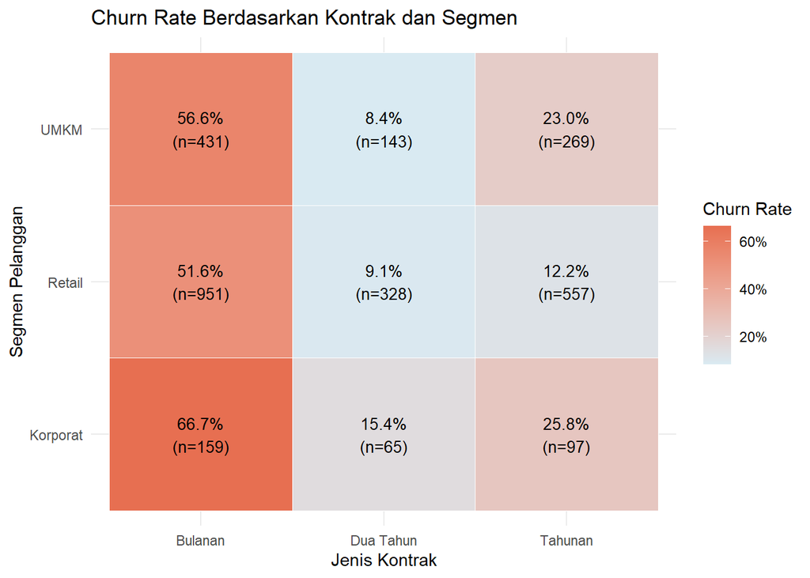

```r
contract_segment <- customer_churn %>%
  group_by(contract_type, segment) %>%
  summarise(
    total_customer = n(),
    total_churn = sum(churn == "Churn"),
    churn_rate = total_churn / total_customer,
    .groups = "drop"
  )

ggplot(
  contract_segment,
  aes(
    x = contract_type,
    y = segment,
    fill = churn_rate
  )
) +
  geom_tile(color = "white") +
  geom_text(
    aes(
      label = paste0(
        percent(churn_rate, accuracy = 0.1),
        "\n(n=", total_customer, ")"
      )
    ),
    size = 3.5
  ) +
  scale_fill_gradient(
    low = "#D9EAF2",
    high = "#E76F51",
    labels = percent
  ) +
  labs(
    title = "Churn Rate Berdasarkan Kontrak dan Segmen",
    x = "Jenis Kontrak",
    y = "Segmen Pelanggan",
    fill = "Churn Rate"
  ) +
  theme_minimal()
```

## 11.2 Churn Berdasarkan Wilayah dan Jenis Kontrak

**Tampilkan / Sembunyikan Kode**

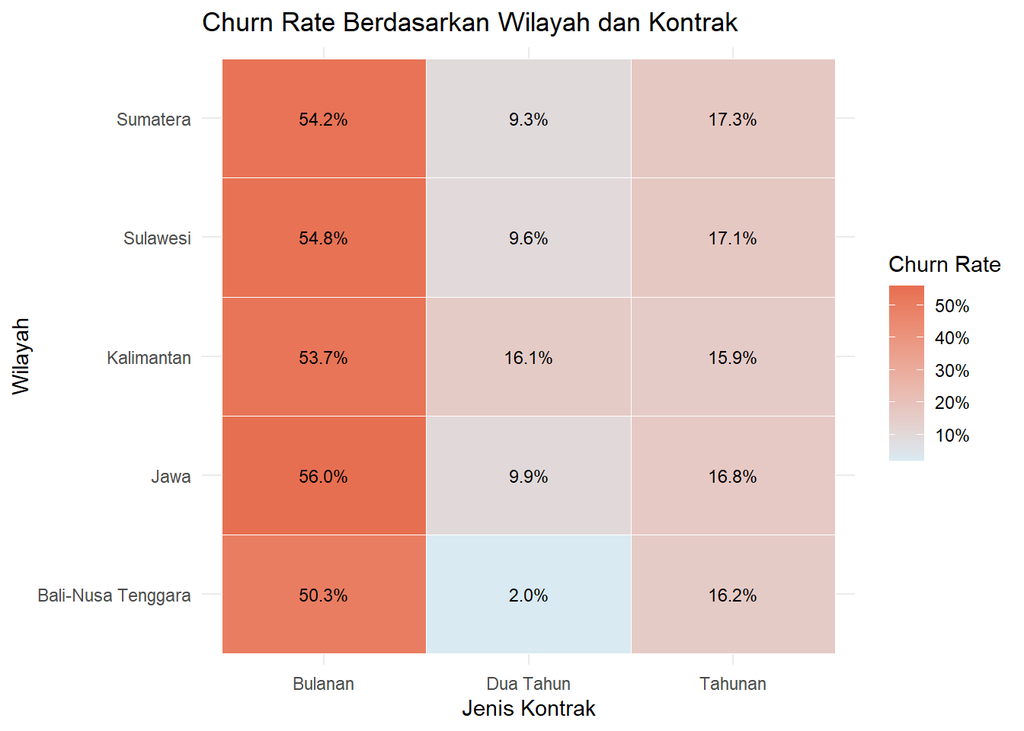

```r
region_contract <- customer_churn %>%
  group_by(region, contract_type) %>%
  summarise(
    total_customer = n(),
    total_churn = sum(churn == "Churn"),
    churn_rate = total_churn / total_customer,
    .groups = "drop"
  )

ggplot(
  region_contract,
  aes(
    x = contract_type,
    y = region,
    fill = churn_rate
  )
) +
  geom_tile(color = "white") +
  geom_text(
    aes(label = percent(churn_rate, accuracy = 0.1)),
    size = 3
  ) +
  scale_fill_gradient(
    low = "#D9EAF2",
    high = "#E76F51",
    labels = percent
  ) +
  labs(
    title = "Churn Rate Berdasarkan Wilayah dan Kontrak",
    x = "Jenis Kontrak",
    y = "Wilayah",
    fill = "Churn Rate"
  ) +
  theme_minimal()
```

# 12 Summary and Business Insights

## 12.1 Ringkasan Churn Berdasarkan Variabel Kategorikal

Tabel berikut digunakan untuk membandingkan churn rate pada setiap kategori.

**Tampilkan / Sembunyikan Kode**

```r
categorical_summary <- bind_rows(
  customer_churn %>%
    group_by(region) %>%
    summarise(
      variable = "Region",
      category = as.character(first(region)),
      total_customer = n(),
      total_churn = sum(churn == "Churn"),
      churn_rate = total_churn / total_customer,
      .groups = "drop"
    ) %>%
    select(variable, category, total_customer, total_churn, churn_rate),

  customer_churn %>%
    group_by(segment) %>%
    summarise(
      variable = "Segment",
      category = as.character(first(segment)),
      total_customer = n(),
      total_churn = sum(churn == "Churn"),
      churn_rate = total_churn / total_customer,
      .groups = "drop"
    ) %>%
    select(variable, category, total_customer, total_churn, churn_rate),

  customer_churn %>%
    group_by(contract_type) %>%
    summarise(
      variable = "Contract",
      category = as.character(first(contract_type)),
      total_customer = n(),
      total_churn = sum(churn == "Churn"),
      churn_rate = total_churn / total_customer,
      .groups = "drop"
    ) %>%
    select(variable, category, total_customer, total_churn, churn_rate),

  customer_churn %>%
    group_by(payment_method) %>%
    summarise(
      variable = "Payment Method",
      category = as.character(first(payment_method)),
      total_customer = n(),
      total_churn = sum(churn == "Churn"),
      churn_rate = total_churn / total_customer,
      .groups = "drop"
    ) %>%
    select(variable, category, total_customer, total_churn, churn_rate),

  customer_churn %>%
    group_by(internet_service) %>%
    summarise(
      variable = "Internet Service",
      category = as.character(first(internet_service)),
      total_customer = n(),
      total_churn = sum(churn == "Churn"),
      churn_rate = total_churn / total_customer,
      .groups = "drop"
    ) %>%
    select(variable, category, total_customer, total_churn, churn_rate)
)

categorical_summary %>%
  arrange(desc(churn_rate)) %>%
  mutate(churn_rate = percent(churn_rate, accuracy = 0.1)) %>%
  knitr::kable(
    caption = "Churn Rate Berdasarkan Kategori Pelanggan"
  )
```

Churn Rate Berdasarkan Kategori Pelanggan

| variable | category | total_customer | total_churn | churn_rate |
| --- | --- | --- | --- | --- |
| Contract | Bulanan | 1541 | 841 | 54.6% |
| Segment | Korporat | 321 | 141 | 43.9% |
| Payment Method | Transfer Bank | 901 | 351 | 39.0% |
| Segment | UMKM | 843 | 318 | 37.7% |
| Region | Kalimantan | 332 | 124 | 37.3% |
| Region | Sumatera | 670 | 242 | 36.1% |
| Internet Service | Mobile Broadband | 643 | 228 | 35.5% |
| Region | Sulawesi | 430 | 150 | 34.9% |
| Internet Service | DSL | 926 | 323 | 34.9% |
| Internet Service | Fiber | 1431 | 497 | 34.7% |
| Region | Jawa | 1262 | 436 | 34.5% |
| Payment Method | E-Wallet | 862 | 293 | 34.0% |
| Payment Method | Kartu Kredit | 653 | 221 | 33.8% |
| Segment | Retail | 1836 | 589 | 32.1% |
| Region | Bali-Nusa Tenggara | 306 | 96 | 31.4% |
| Payment Method | Virtual Account | 584 | 183 | 31.3% |
| Contract | Tahunan | 923 | 155 | 16.8% |
| Contract | Dua Tahun | 536 | 52 | 9.7% |

## 12.2 Faktor dengan Churn Rate Tertinggi

**Tampilkan / Sembunyikan Kode**

```r
categorical_summary %>%
  group_by(variable) %>%
  slice_max(
    order_by = churn_rate,
    n = 1,
    with_ties = FALSE
  ) %>%
  ungroup() %>%
  mutate(
    churn_rate = percent(churn_rate, accuracy = 0.1)
  ) %>%
  knitr::kable(
    caption = "Kategori dengan Churn Rate Tertinggi pada Setiap Variabel"
  )
```

Kategori dengan Churn Rate Tertinggi pada Setiap Variabel

| variable | category | total_customer | total_churn | churn_rate |
| --- | --- | --- | --- | --- |
| Contract | Bulanan | 1541 | 841 | 54.6% |
| Internet Service | Mobile Broadband | 643 | 228 | 35.5% |
| Payment Method | Transfer Bank | 901 | 351 | 39.0% |
| Region | Kalimantan | 332 | 124 | 37.3% |
| Segment | Korporat | 321 | 141 | 43.9% |

## 12.3 Rangkuman Statistik Numerik Berdasarkan Churn

**Tampilkan / Sembunyikan Kode**

```r
customer_churn %>%
  group_by(churn) %>%
  summarise(
    total_customer = n(),
    avg_tenure = mean(tenure_months),
    avg_monthly_charges = mean(monthly_charges),
    avg_total_charges = mean(total_charges, na.rm = TRUE),
    avg_complaints = mean(num_complaints),
    avg_support_calls = mean(support_calls),
    .groups = "drop"
  ) %>%
  knitr::kable(
    digits = 2,
    caption = "Rata-rata Karakteristik Pelanggan Berdasarkan Status Churn"
  )
```

Rata-rata Karakteristik Pelanggan Berdasarkan Status Churn

| churn | total_customer | avg_tenure | avg_monthly_charges | avg_total_charges | avg_complaints | avg_support_calls |
| --- | --- | --- | --- | --- | --- | --- |
| Tidak Churn | 1952 | 30.45 | 413204.4 | 12727327 | 0.98 | 2.24 |
| Churn | 1048 | 19.21 | 443971.4 | 8647159 | 1.40 | 2.78 |

## 12.4 Kesimpulan dan Insight

Berdasarkan seluruh proses Exploratory Data Analysis, beberapa aspek yang perlu diperhatikan adalah:

1. **Customer Churn:** Mengidentifikasi proporsi pelanggan yang berhenti berlangganan dibandingkan pelanggan yang masih aktif.
2. **Customer Segmentation:** Mengetahui wilayah dan segmen pelanggan yang memiliki tingkat churn relatif tinggi.
3. **Contract Type:** Membandingkan tingkat churn berdasarkan jenis kontrak untuk melihat apakah pelanggan dengan kontrak bulanan memiliki kecenderungan churn yang berbeda dari kontrak jangka panjang.
4. **Customer Tenure:** Menganalisis hubungan antara lama berlangganan dengan status churn, khususnya apakah pelanggan dengan masa berlangganan lebih singkat menunjukkan tingkat churn lebih tinggi.
5. **Financial Analysis:** Mengidentifikasi perbedaan biaya bulanan dan total biaya antara pelanggan yang churn dan tidak churn.
6. **Customer Experience:** Menganalisis apakah jumlah keluhan dan panggilan customer support memiliki pola hubungan dengan churn.
7. **Customer Behavior:** Menggabungkan beberapa variabel untuk menemukan kelompok pelanggan yang perlu mendapatkan perhatian lebih.

Hasil EDA ini dapat digunakan sebagai dasar untuk menentukan variabel yang akan dianalisis lebih lanjut dalam tahap pemodelan Machine Learning, khususnya prediksi Customer Churn.

Perlu diperhatikan bahwa hubungan antarvariabel dalam EDA tidak secara otomatis menunjukkan hubungan sebab-akibat. Analisis lanjutan diperlukan untuk menguji temuan tersebut.

# 13 Export Clean Dataset

Dataset yang telah melalui proses cleaning dapat disimpan untuk digunakan dalam analisis selanjutnya.

**Tampilkan / Sembunyikan Kode**

```r
write.csv(
  customer_churn,
  "customer_churn_clean.csv",
  row.names = FALSE
)
```

**End of Exploratory Data Analysis - Customer Churn**